Summary of Analyses of Great Lakes Mysis diluviana Abundance and Life History Trends During 1990-2019 ================

# Contents:

Load Libraries Section 1: Evaluate GLNPO Zooplankton Net Data  
…1… Conclusions  
Section 2: Upload Remaining Annual Program Datasets  
Section 3: Compare Lakes  
Section 4: Trends Within Lakes  
…4… GAM results plotted  
Section 5: Life History Data  
…5… Fecundity and Brooding Female Lengths  
…5… Size and Growth  
…5… Age Structure and Survival  
Section 6: Food resources

#### Load package libraries

```r
# In order of occurrence

library(tidyverse) # for tidyverse functions and pipe operator

library(knitr) # for kable() function

# library(skimr) # for skim() function

library(geosphere) # for maps()

library(lme4)

library(mclust) # for Mclust() function

library(mgcv) # for gam() functions

library(MuMIn) # for AICc() function

library(zoo)
```

# 1. Upload GLNPO Data and Evaluate Usability of Zooplankton Net Mysid Catches

## Begin plotting relationships between nets

First, which variable on ‘Y’ and which on ‘X’ axis? Plot the more variable data on the ‘Y’ axis.

Mysid net data are likely to be less variable than Zooplankton net data, because the mysid data is based on sampling of about 8x more area than the zooplankton net. The mysid net opening is 0.785, and is towed twice. The zooplankton net opening is 0.196, and is towed just once.

This is borne out by comparing their CV’s in this dataset:

- Mysid Net Density CV: 1.15
- Zoop Net Density CV: 1.51
- Mysid Net Biomass CV: 1.08
- Zoop Net Biomass CV: 2.09

OK: plot `Zoop...` data on ‘Y’ axis and `Mys...` data on ‘X’ axis.

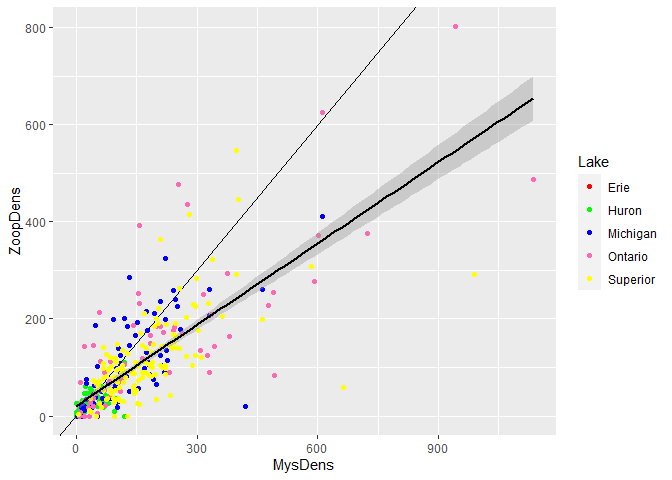

*(Adjusted r^2 values for the linear fits plotted above):*

- *Density: 0.61*
- *Biomass: 0.33*

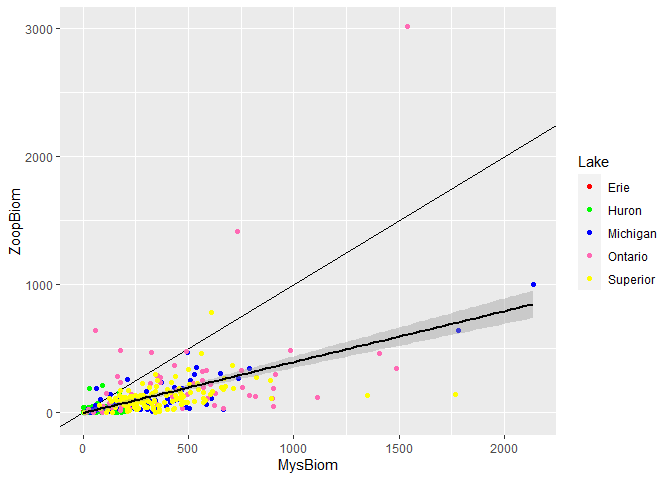

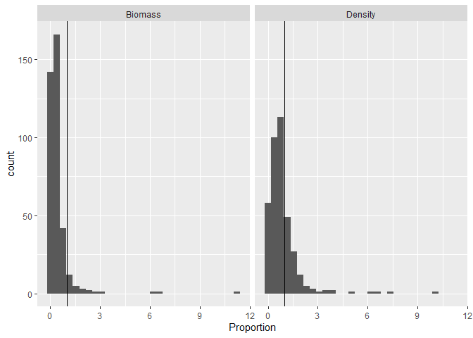

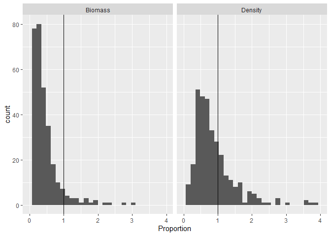

```
## # A tibble: 1 x 2
##   Density_Proportion Biomass_Proportion
##                <dbl>              <dbl>
## 1              0.854              0.424

## # A tibble: 1 x 2
##   Density_Proportion_geomean Biomass_Proportion_geomean
##                        <dbl>                      <dbl>
## 1                      0.754                      0.289

## # A tibble: 1 x 4
##   Density_Proporti~ Biomass_Proporti~ Density_Proportion_g~ Biomass_Proportion_~
##               <dbl>             <dbl>                 <dbl>                <dbl>
## 1             0.769             0.370                 0.696                0.276
```

Conclusions:

- Correlations look good. Can use the data.
- Lines do not seem to match 1:1 lines nor include them in confidence intervals. Zooplankton net values cannot be considered the same as the values one would obtain with mysid net.

Transform density data?

1. Linear (untransformed) data
2. Log_e transformed data
3. Square-root transformed data
4. Fourth-root transformed data

### Transformation conclusion:

- The diagnostics look pretty good for most of the transformations on the whole.
- Linear has issues with scale-location (density and biomass), leverage points (density and biomass), and normality (density and biomass).
- Natural Log has issues with homoscedasticity (biomass and perhaps density) and perhaps normality (density).
- Square-Root has issues with scale-location (density and perhaps biomass), leverage points (just biomass) and normality (biomass and perhaps density).
- Fourth-Root may have a slight issue with homoscedasticity, but no more than the others and scale loction looks better (density and biomass).

## 4th-Root Transformation Fit: Stats and Plots

```
## [1] "Density 4th-Root Fit Statistics:"

##               Estimate Std. Error t value     Pr(>|t|)
## (Intercept) -0.2903798 0.10329757 -2.8111 5.189637e-03
## MysDens      0.9640695 0.03329797 28.9528 1.106590e-98

## [1] "Adjusted r^2:"

## [1] 0.684451

## Warning: Removed 9 rows containing non-finite values (stat_smooth).

## Warning: Removed 9 rows containing missing values (geom_point).
```

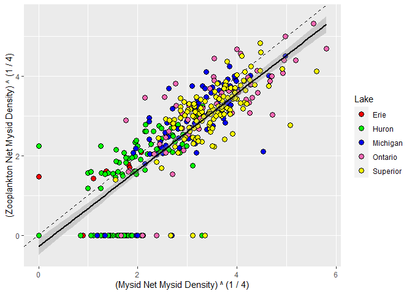

```
## [1] "Biomass 4th-Root Fit Statistics:"

##               Estimate Std. Error   t value     Pr(>|t|)
## (Intercept) -0.4361253 0.12047018 -3.620193 3.337152e-04
## MysBiom      0.8229876 0.03207529 25.657992 2.307141e-85

## [1] "Adjusted r^2:"

## [1] 0.6300317

## Warning: Removed 9 rows containing non-finite values (stat_smooth).

## Warning: Removed 9 rows containing missing values (geom_point).
```

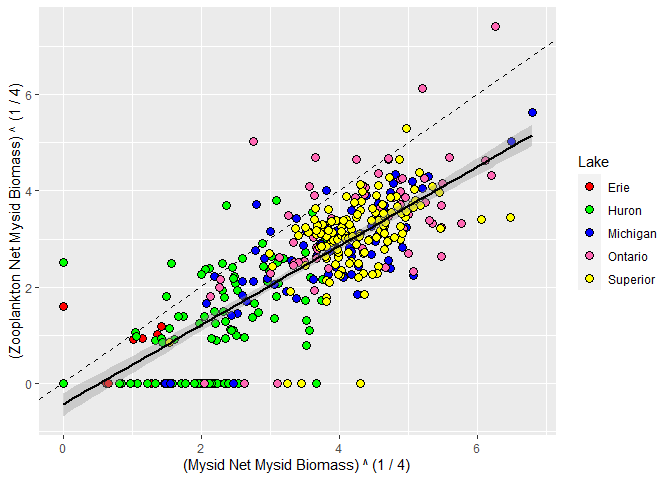

#### Clearly these data are worth using for *Mysis diluviana* in the Great Lakes.

- Zoop net data will correctly display direction and relative magnitude of any changes over time or between lakes.
- Zoop net data will probably not representvalues similar to Mysid net data.
- For densities from the Zoop net, the values themselves are only different from the higher Mysid net values by a constant negative offset when 4th-root transformed.

n = 396

#### *Some other observations:*

- *There are some points that show up clearly in the plots of transformed data where 0 mysids were caught in the zooplankton net while at least 1 mysid was caught in the mysid net.*
  - *These points behave nicely with the rest of the data, especially in the 4th-root case.*
  - *We also no longer intend to convert the zooplankton net values to predicted ‘mysid’ net values for the subsequent analyses, so these 0’s in the zooplankton net become unconcerning for those portions.*
- *The fact that 4th-root transformed variables turn out to be just an offset of each other is good for subsequent GAM analyses.*
  - *When we tranform the data later on for the GAM, and include collection procedure (`ColPrcdr`) as a non-smoothed additive categorical predictor, this should work out well.*
  - *It may make sense at that time to try square-root or 4th-root tranformation rather than natural log.*
    - *For the present data (with `Zoop...` on ‘Y’ and `Mys...` on ‘X’), we find that 4th-root performs best.*
    - *When we had previously intended to predict mysid net catches from zooplankton net catches, we had modeled these data with `Mys...` on ‘Y’ and `Zoop...` on ‘X’). In that case, natural log transformation worked best. Perhaps square-root (which is somewhere in-between in degree of transformation) would be best for the GAM model. Just take a look at what makes the most sense when it comes to that point.*

# 2. Upload Remaining Annual Monitoring Data And Compile Into Single Tibble Object

### Load GLNPO Mysid Net Data

Mysid net data exist in GLNPO Zoop Net tibble dataframe `GLNPO`, but in that tibble they are organized by zooplankton net tow ID, rather than mysid net tow ID. Some mysid tows are taken even when zoop tows are not. I.e.:

1. At summer benthic stations (from which zooplankton are not collected but mysids often are), or
2. During the occasional station with weather safety concerns that halt sampling operations in-between mysid and zooplaknton net tows. *This latter case has happened at least once during a CSMI survey, but has perhaps never occurred during a GLNPO survey*

Therefore, a seperate mysid-net-tow specific tibble is needed to represent that dataset.

### Load NOAA GLERL Muskegon Mysid Data

### Load USGS GLSC Mysid Net Data From Annual Acoustic Surveys in Lakes Michigan and Huron

### Upload DFO data into tibble

## Compile data sources into single tibble

### Examine `Mysids` tibble

```
## # A tibble: 2,010 x 16
## # Groups:   Visit, Lake, Year, Season [1,653]
##    Visit Lake   Year Season Station Date       StationDepth DepthZone   Dens
##    <chr> <fct> <dbl> <fct>  <chr>   <date>            <dbl> <fct>      <dbl>
##  1 E009~ Erie   2000 Spring ER09    2000-04-16           49 Mid-depth NaN
##  2 E009~ Erie   2000 Summer ER09    2000-08-04           30 Mid-depth   0
##  3 E009~ Erie   2001 Summer ER09    2001-08-05           51 Mid-depth  15.2
##  4 E009~ Erie   2002 Summer ER09    2002-08-08           48 Mid-depth   0
##  5 E009~ Erie   2008 Summer ER09    2008-08-11           49 Mid-depth   6.79
##  6 E009~ Erie   2009 Summer ER09    2009-08-19           49 Mid-depth   0
##  7 E009~ Erie   2010 Summer ER09    2010-08-11           49 Mid-depth   0
##  8 E009~ Erie   2014 Summer ER09    2014-08-15           49 Mid-depth   0
##  9 E009~ Erie   2015 Summer ER09    2015-08-13           49 Mid-depth  10.1
## 10 E009~ Erie   2018 Summer ER09    2018-08-13           49 Mid-depth  19.0
## # ... with 2,000 more rows, and 7 more variables: Biom <dbl>, DN <chr>,
## #   TimeEDT <dttm>, Group <fct>, Period <chr>, Period_Name <fct>,
## #   Period_Numeric <dbl>
```

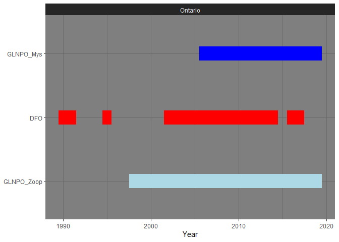

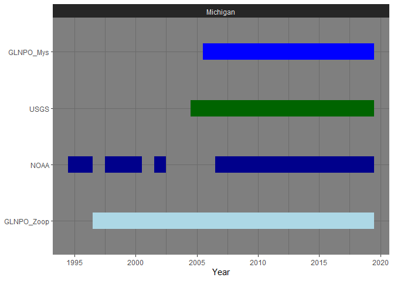

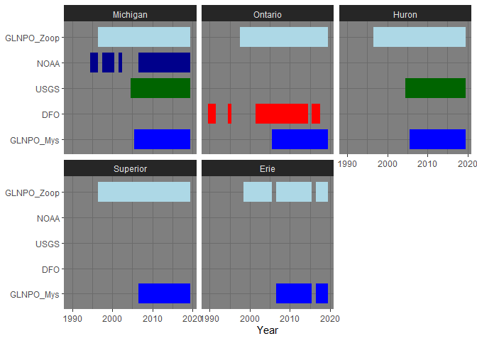

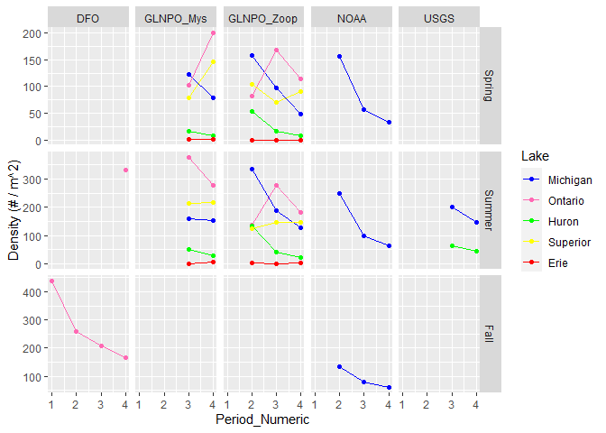

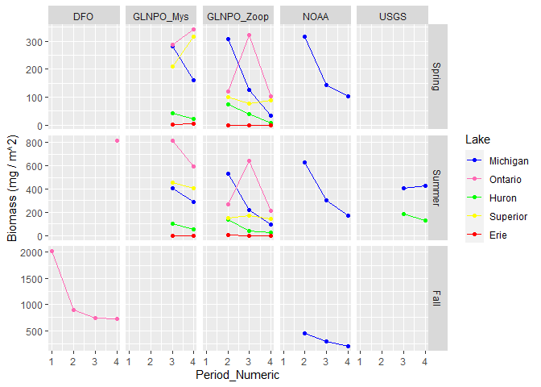

| Period_Numeric | Period_Name | Period | Lake | Group | N_Years | dens_Spring | se2_dens_Spring | biom_Spring | se2_biom_Spring | dens_Summer | se2_dens_Summer | biom_Summer | se2_biom_Summer | dens_Fall | se2_dens_Fall | biom_Fall | se2_biom_Fall |
| --- | --- | --- | --- | --- | --- | --- | --- | --- | --- | --- | --- | --- | --- | --- | --- | --- | --- |
| 1 | Early1990s | 1990-1995 | Ontario | DFO | 3 | - | - | - | - | - | - | - | - | 438.9 | 101.48762 | 2022.2617 | 915.12314 |
| 2 | Early2000s | 1997-2004 | Superior | GLNPO_Zoop | 7 | 104.6 | 31.1313915 | 98.453586 | 58.231530 | - | - | - | - | - | - | - | - |
| 2 | Early2000s | 1997-2004 | Superior | GLNPO_Zoop | 8 | - | - | - | - | 125.1 | 27.738535 | 154.0695466 | 68.030778 | - | - | - | - |
| 2 | Early2000s | 1997-2004 | Michigan | GLNPO_Zoop | 7 | 158.7 | 57.0132888 | 306.802206 | 224.054347 | - | - | - | - | - | - | - | - |
| 2 | Early2000s | 1997-2004 | Michigan | GLNPO_Zoop | 8 | - | - | - | - | 333.8 | 126.860047 | 528.1740625 | 311.409479 | - | - | - | - |
| 2 | Early2000s | 1995-2002 | Michigan | NOAA | 6 | 155.6 | 43.3567834 | 315.514202 | 106.137311 | 247.5 | 81.514089 | 629.6174626 | 210.983290 | - | - | - | - |
| 2 | Early2000s | 1995-2002 | Michigan | NOAA | 4 | - | - | - | - | - | - | - | - | 132.8 | 65.48068 | 444.1379 | 193.57174 |
| 2 | Early2000s | 1997-2004 | Huron | GLNPO_Zoop | 7 | 53.3 | 34.7403351 | 72.459048 | 67.904622 | - | - | - | - | - | - | - | - |
| 2 | Early2000s | 1997-2004 | Huron | GLNPO_Zoop | 8 | - | - | - | - | 135.2 | 59.722118 | 134.3617361 | 45.352431 | - | - | - | - |
| 2 | Early2000s | 1997-2004 | Erie | GLNPO_Zoop | 2 | 0.0 | 0.0000000 | 0.000000 | 0.000000 | - | - | - | - | - | - | - | - |
| 2 | Early2000s | 1997-2004 | Erie | GLNPO_Zoop | 6 | - | - | - | - | 3.2 | 3.555934 | 3.7466667 | 6.834779 | - | - | - | - |
| 2 | Early2000s | 1997-2004 | Ontario | GLNPO_Zoop | 7 | 82.3 | 22.9770900 | 120.258675 | 44.514564 | 136.0 | 46.334918 | 267.8323810 | 147.271768 | - | - | - | - |
| 2 | Early2000s | 2002-2004 | Ontario | DFO | 3 | - | - | - | - | - | - | - | - | 258.5 | 80.22128 | 894.6626 | 291.59765 |
| 3 | Late2000s | 2005-2012 | Superior | GLNPO_Mys | 6 | 78.4 | 15.4607460 | 208.582261 | 41.729525 | 212.7 | 68.788268 | 456.4053394 | 149.201311 | - | - | - | - |
| 3 | Late2000s | 2005-2012 | Superior | GLNPO_Zoop | 8 | 70.1 | 13.9258111 | 77.068763 | 18.129508 | 146.3 | 43.004642 | 174.5497391 | 60.005557 | - | - | - | - |
| 3 | Late2000s | 2005-2012 | Michigan | GLNPO_Mys | 7 | 122.6 | 29.8803783 | 282.455408 | 81.323783 | 158.3 | 65.705662 | 407.5532208 | 257.483632 | - | - | - | - |
| 3 | Late2000s | 2005-2012 | Michigan | GLNPO_Zoop | 8 | 96.6 | 22.8863262 | 126.684097 | 55.406862 | 188.6 | 63.561385 | 218.2483125 | 120.222592 | - | - | - | - |
| 3 | Late2000s | 2005-2012 | Michigan | USGS | 8 | - | - | - | - | 200.1 | 73.329340 | 406.2924396 | 274.420574 | - | - | - | - |
| 3 | Late2000s | 2007-2012 | Michigan | NOAA | 6 | 56.6 | 27.1195747 | 143.240538 | 69.939047 | 99.7 | 35.499772 | 301.0590633 | 122.258292 | 78.6 | 23.63709 | 291.2230 | 77.13195 |
| 3 | Late2000s | 2005-2012 | Huron | GLNPO_Mys | 7 | 16.5 | 6.5842525 | 42.425682 | 16.053898 | 51.0 | 11.318734 | 102.7886941 | 27.131868 | - | - | - | - |
| 3 | Late2000s | 2005-2012 | Huron | GLNPO_Zoop | 8 | 16.2 | 12.7149764 | 40.040979 | 44.786835 | 43.1 | 27.928582 | 40.7621875 | 30.442615 | - | - | - | - |
| 3 | Late2000s | 2005-2012 | Huron | USGS | 8 | - | - | - | - | 64.2 | 13.855582 | 182.5468246 | 66.910794 | - | - | - | - |
| 3 | Late2000s | 2005-2012 | Erie | GLNPO_Mys | 3 | 0.2 | 0.4000000 | 1.574510 | 3.149019 | - | - | - | - | - | - | - | - |
| 3 | Late2000s | 2005-2012 | Erie | GLNPO_Mys | 5 | - | - | - | - | 1.0 | 1.070701 | 0.6803465 | 1.054176 | - | - | - | - |
| 3 | Late2000s | 2005-2012 | Erie | GLNPO_Zoop | 4 | 0.0 | 0.0000000 | 0.000000 | 0.000000 | - | - | - | - | - | - | - | - |
| 3 | Late2000s | 2005-2012 | Erie | GLNPO_Zoop | 6 | - | - | - | - | 1.4 | 1.197405 | 0.7328704 | 1.046704 | - | - | - | - |
| 3 | Late2000s | 2005-2012 | Ontario | GLNPO_Mys | 7 | 101.8 | 42.1117108 | 286.764401 | 166.923125 | - | - | - | - | - | - | - | - |
| 3 | Late2000s | 2005-2012 | Ontario | GLNPO_Mys | 6 | - | - | - | - | 377.4 | 281.881079 | 817.2096724 | 337.113836 | - | - | - | - |
| 3 | Late2000s | 2005-2012 | Ontario | GLNPO_Zoop | 8 | 168.6 | 84.8490756 | 322.764722 | 323.803647 | 277.8 | 125.595942 | 640.7952778 | 397.487250 | - | - | - | - |
| 3 | Late2000s | 2005-2012 | Ontario | DFO | 8 | - | - | - | - | - | - | - | - | 208.5 | 47.98850 | 741.8831 | 157.29927 |
| 4 | The2010s | 2013-2019 | Superior | GLNPO_Mys | 7 | 145.6 | 29.3604667 | 317.849844 | 64.779173 | 216.0 | 22.905888 | 406.9472826 | 47.602963 | - | - | - | - |
| 4 | The2010s | 2013-2019 | Superior | GLNPO_Zoop | 6 | 91.3 | 32.8117730 | 87.362706 | 25.052449 | - | - | - | - | - | - | - | - |
| 4 | The2010s | 2013-2019 | Superior | GLNPO_Zoop | 7 | - | - | - | - | 146.0 | 36.582528 | 145.0759348 | 42.237851 | - | - | - | - |
| 4 | The2010s | 2013-2019 | Michigan | GLNPO_Mys | 7 | 79.3 | 32.9757610 | 160.120079 | 50.199692 | 152.9 | 50.207854 | 292.2681102 | 87.157039 | - | - | - | - |
| 4 | The2010s | 2013-2019 | Michigan | GLNPO_Zoop | 6 | 48.3 | 28.3899826 | 33.796889 | 18.057061 | - | - | - | - | - | - | - | - |
| 4 | The2010s | 2013-2019 | Michigan | GLNPO_Zoop | 7 | - | - | - | - | 126.8 | 42.570534 | 96.7355782 | 41.134571 | - | - | - | - |
| 4 | The2010s | 2013-2019 | Michigan | USGS | 7 | - | - | - | - | 146.2 | 60.208660 | 425.7113715 | 214.418410 | - | - | - | - |
| 4 | The2010s | 2013-2019 | Michigan | NOAA | 7 | 32.3 | 18.5414043 | 102.458025 | 54.047760 | 65.4 | 38.383464 | 171.4278387 | 96.842725 | 60.1 | 30.68028 | 200.5816 | 106.78808 |
| 4 | The2010s | 2013-2019 | Huron | GLNPO_Mys | 7 | 8.2 | 3.1640842 | 20.621588 | 9.235574 | 30.0 | 6.314566 | 58.0021577 | 12.677054 | - | - | - | - |
| 4 | The2010s | 2013-2019 | Huron | GLNPO_Zoop | 6 | 7.6 | 2.6059760 | 6.811528 | 4.172382 | - | - | - | - | - | - | - | - |
| 4 | The2010s | 2013-2019 | Huron | GLNPO_Zoop | 7 | - | - | - | - | 22.9 | 12.309921 | 23.8342619 | 19.725323 | - | - | - | - |
| 4 | The2010s | 2013-2019 | Huron | USGS | 7 | - | - | - | - | 44.7 | 10.346540 | 129.9227526 | 40.970052 | - | - | - | - |
| 4 | The2010s | 2013-2019 | Erie | GLNPO_Mys | 5 | 0.6 | 0.9436101 | 4.349987 | 6.273840 | - | - | - | - | - | - | - | - |
| 4 | The2010s | 2013-2019 | Erie | GLNPO_Mys | 4 | - | - | - | - | 6.6 | 6.305751 | 1.7067676 | 1.685544 | - | - | - | - |
| 4 | The2010s | 2013-2019 | Erie | GLNPO_Zoop | 4 | 0.0 | 0.0000000 | 0.000000 | 0.000000 | - | - | - | - | - | - | - | - |
| 4 | The2010s | 2013-2019 | Erie | GLNPO_Zoop | 5 | - | - | - | - | 3.1 | 3.363332 | 1.0018333 | 1.403028 | - | - | - | - |
| 4 | The2010s | 2013-2019 | Ontario | GLNPO_Mys | 7 | 199.6 | 59.6789004 | 341.343259 | 90.552405 | 278.2 | 122.582378 | 590.9944744 | 180.337017 | - | - | - | - |
| 4 | The2010s | 2013-2019 | Ontario | GLNPO_Zoop | 6 | 114.4 | 30.3016685 | 101.942500 | 53.686654 | - | - | - | - | - | - | - | - |
| 4 | The2010s | 2013-2019 | Ontario | GLNPO_Zoop | 7 | - | - | - | - | 182.3 | 56.591425 | 213.8916190 | 64.652506 | - | - | - | - |
| 4 | The2010s | 2013-2017 | Ontario | DFO | 1 | - | - | - | - | 332.6 | - | 815.2259259 | - | - | - | - | - |
| 4 | The2010s | 2013-2017 | Ontario | DFO | 4 | - | - | - | - | - | - | - | - | 164.8 | 39.21593 | 724.0704 | 99.97280 |

### Models of Lake Differences

Summer Mean Values:

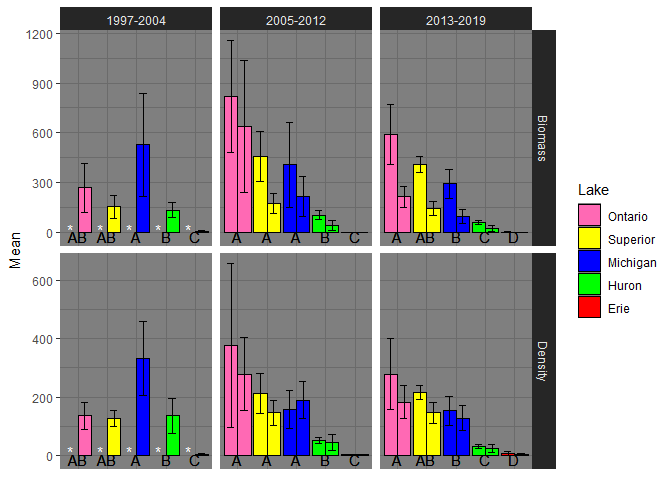

# 4. Examine Time Series Trends in Each Lake

### Plot trends with smoother gams for each season, group and lake.

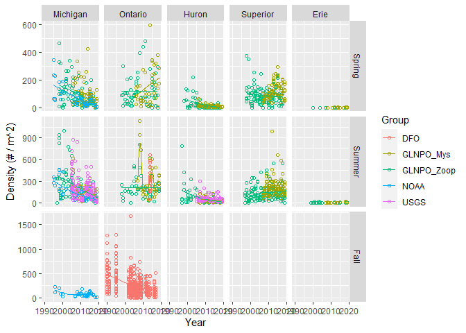

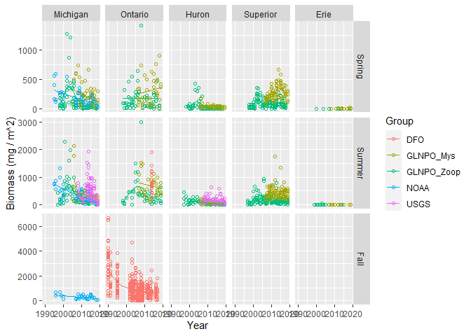

### Fit GAM models for each Lake

For most of the lakes, `Season` effects do not change over time (`Year`). `Group` effects do change a little bit over time (`Year`). I’m not sure why. The best models account for this. But the simpler models that only smooth the `Year` term are not substantially worse off in terms of AICc.

In Lake Superior, both `Season` and `Group` have significant effects over time (`Year`), while time (`Year`) on its own does not have a significant effect. For Lake Superior, `Season` is more important that `Group`, but `Group` remains important according to AICc.

Based on the plot of data for Lake Superior, these findings are not suprising. The models that smooth over `Season` and `Group` show temporal patterns much more similar to what each seasonal dataset demonstrates on its own (pers. obsv. in previous preliminary analyses). Perhasp for Lake Superior, we should fit a model with a slightly different statistical structure.

### Plot fitted GAM models for each lake by season

**Need to visualize mysid densities:**

- In 4 deep lakes
- Over ~ 20-25 years (1990/1995/1997 - 2019)
- In 2 - 3 seasons
- Collected by 2 - 4 methods/groups

**Plotting Decisions:**

#### Plots below are mean value predicted GAM value +/- 1 SE.

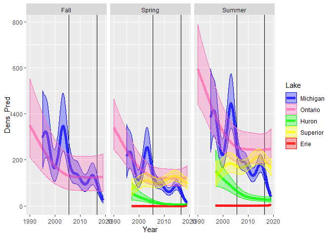

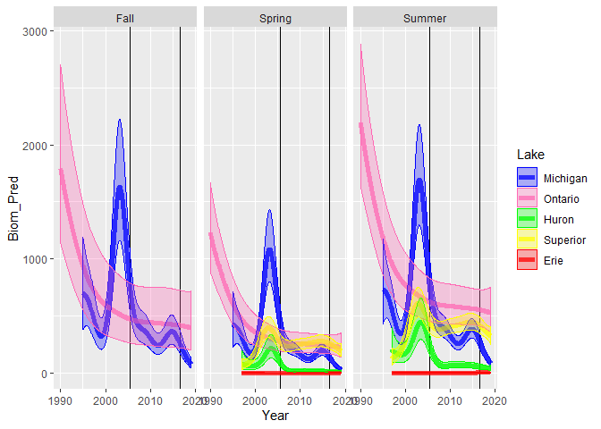

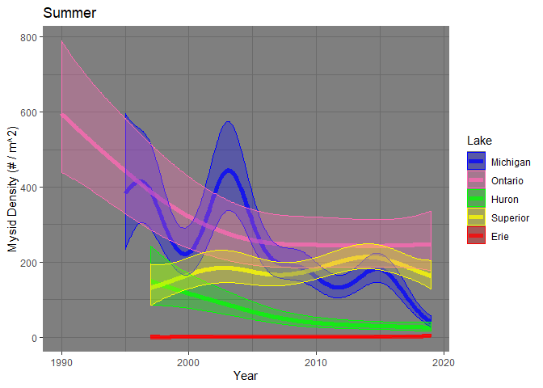

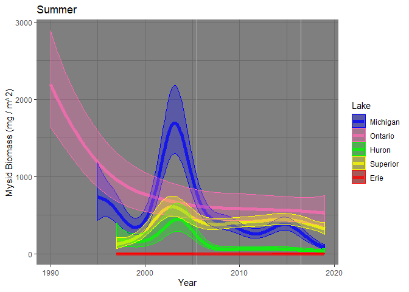

#### …And versions with data plotted for supplementary figure(s):

The plot below shows the same above GAM fits superimposed on model-adjusted data points. The model adjustment in the data points is that of re-predicting the values assuming the GLNPO Mysid net was used to collect the sample. Thus, each point is the predicted GAM value for the lake, season, and year shown and gvien the `GLNPO_Mys` `Group` effect, plus the residual associated with that point’s fit to the GAM.

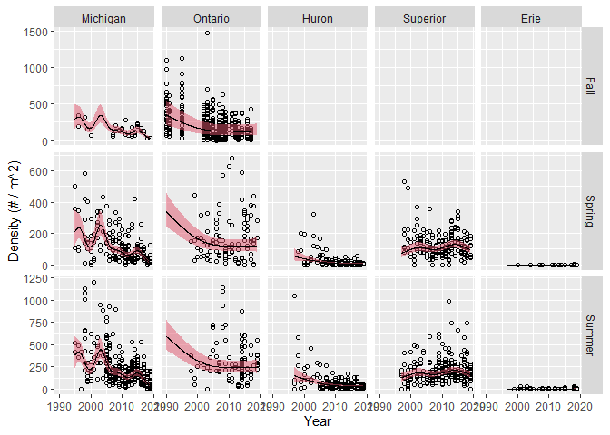

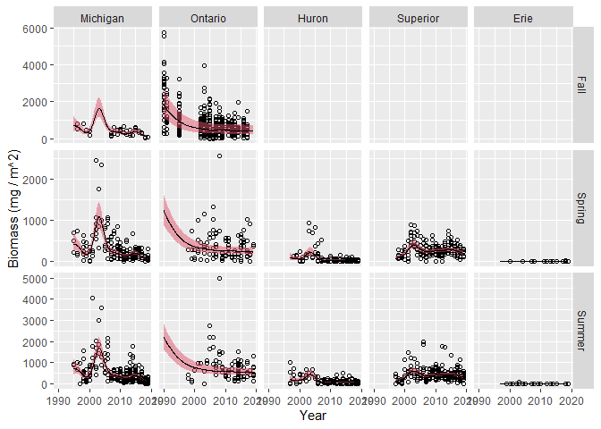

# 5. Examine averages and trends in life history rates in the lakes

## Calculate summary values from life history data

#### Key plots and analyses of Brooding Females data

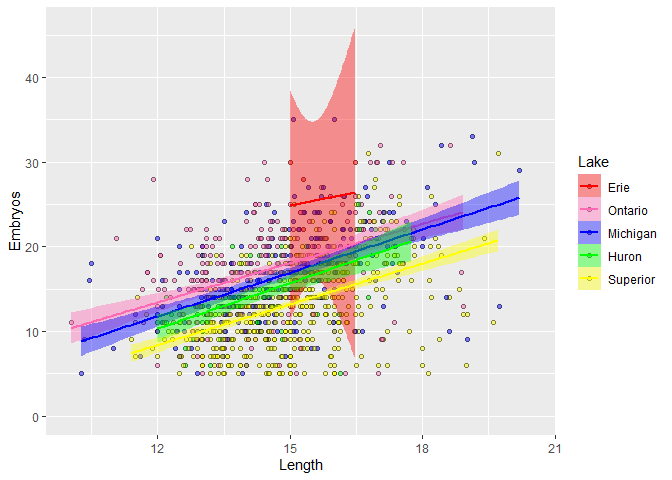

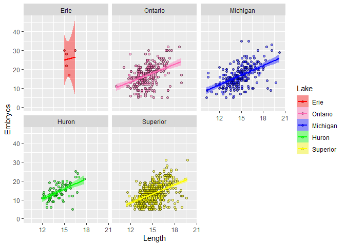

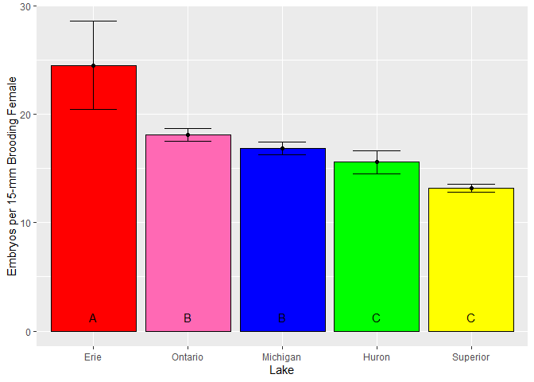

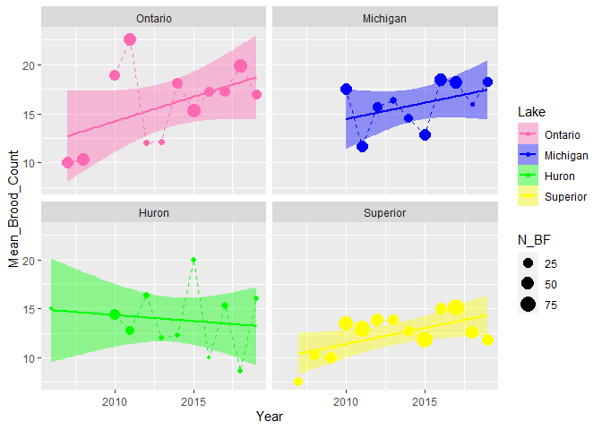

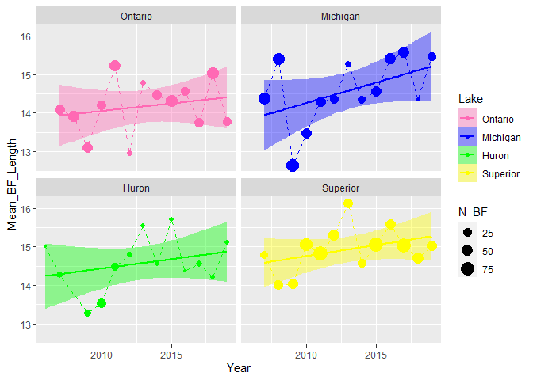

NOAA Values:

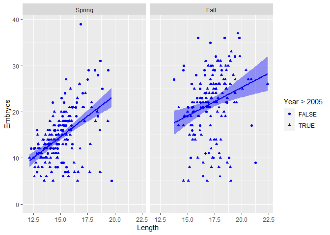

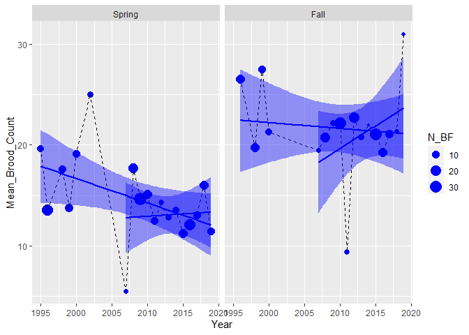

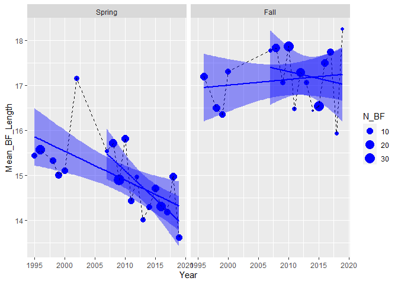